# **Curso**

# *Sobre*

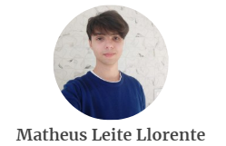

**É um prazer em te conhecer!**

Meu nome é [Matheus Leite Llorente](https://www.linkedin.com/in/matheus-llorente/) e sou discente de Ciências Atuariais pela Universidade Federal de São Paulo. Estudo DataScience desde os meus 16 anos de idade, desenvolvi aptidão em Programação, Análise de Banco de Dados, Análises Preditivas, e, também na Análise Estatística. Maximizo meu conhecimento em leituras, cursos, com Professores e Gestores na área para promover um conteúdo de qualidade para você :). Procurei desenvolver este curso com fins de difusão do conhecimento para constribuição científica tanto dentro da nossa Universidade como fora!

*Espero que goste! :)*

[figure not shown]

Caso queira conhecer mais sobre mim, me siga no [Linkedin](https://www.linkedin.com/in/matheus-llorente/)